# cen_fsus group project

The average british person is white, christian, belongs to the middle class and has a university degree has a average divorce rate of 12 %. By only changing education (but keeping social class) the divorce rate ascends to 14.5 %. When looking for both education extremes in the lowest social class we get a divorce rate for university graduates of 24 % versus 35 % for non educated people. It can be seen by this, that social grade accounts for higher differences in divorce rate than education does.

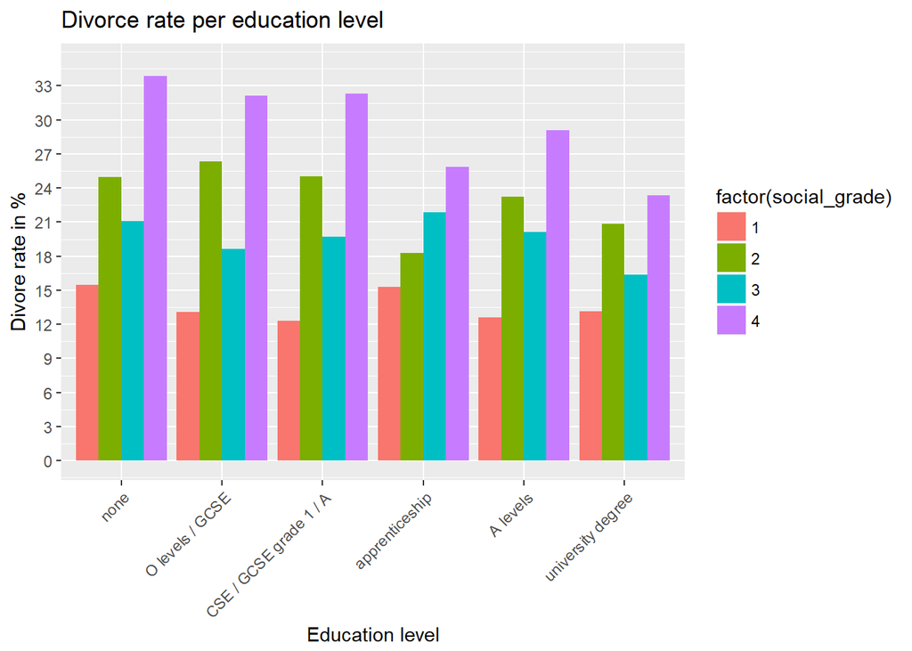

```r
#grouping ethnicity
census$ethngrouped <- census$ethnicityew

census$ethngrouped <- ifelse(census$ethnicityew == "English/Welsh/Scottish/Northern Irish/British"  | census$ethnicityew == "Irish" | census$ethnicityew == "Gypsy or Irish Traveller"| census$ethnicityew == "Other White", 1,
                                ifelse( census$ethnicityew == "Indian" | census$ethnicityew == "Pakistani"| census$ethnicityew == "Bangladeshi" | census$ethnicityew == "Chinese"| census$ethnicityew == "Other Asian", 2,
                                        ifelse(census$ethnicityew == "African" | census$ethnicityew == "Caribbean"| census$ethnicityew == "Other Black", 3,
                                               ifelse(census$ethnicityew == "Arab", 4,
                                                      ifelse(census$ethnicityew == "other", "Any other ethnic group", 5)))))


educ <- cen_f %>% group_by(education, social_grade) %>% summarise(n = n(), separated = sum(separated), rel_div = (separated / n)*100) %>% mutate(sg = n/sum(n))

#add seperation per social grade

edu_plot <- ggplot(educ, aes(x = factor(education), y = rel_div, fill = factor(social_grade)))
edu_plot +
  geom_col(stat = "identity", position = "dodge") +
  scale_x_discrete(labels = c("10" = "none", "11" = "O levels / GCSE", "12" = "CSE / GCSE grade 1 / A", "13" = "apprenticeship", "14" = "A levels", "15" = "university degree")) +
  scale_y_continuous(limits = c(0, 35), breaks = seq(0, 35, 3)) +
  ggtitle("Divorce rate per education level") +
  xlab ("Education level") +
  ylab ("Divore rate in %") +
  theme(axis.text.x = element_text(angle = 45, hjust = 1))
```

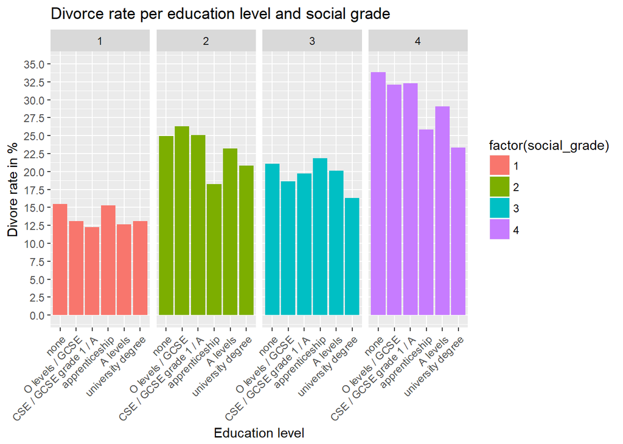

```r
#plot with facet_grid per social grade
####
edu_plot <- ggplot(educ, aes(x = factor(education), y = rel_div, fill = factor(social_grade)))
edu_plot +
  geom_col(stat = "identity") +
  scale_x_discrete(labels = c("10" = "none", "11" = "O levels / GCSE", "12" = "CSE / GCSE grade 1 / A", "13" = "apprenticeship", "14" = "A levels", "15" = "university degree")) +
  scale_y_continuous(limits = c(0, 35), breaks = seq(0, 35, 2.5)) +
  ggtitle("Divorce rate per education level and social grade") +
  xlab ("Education level") +
  ylab ("Divore rate in %") +
  theme(axis.text.x = element_text(angle = 45, hjust = 1)) +
  facet_grid(~social_grade)
```

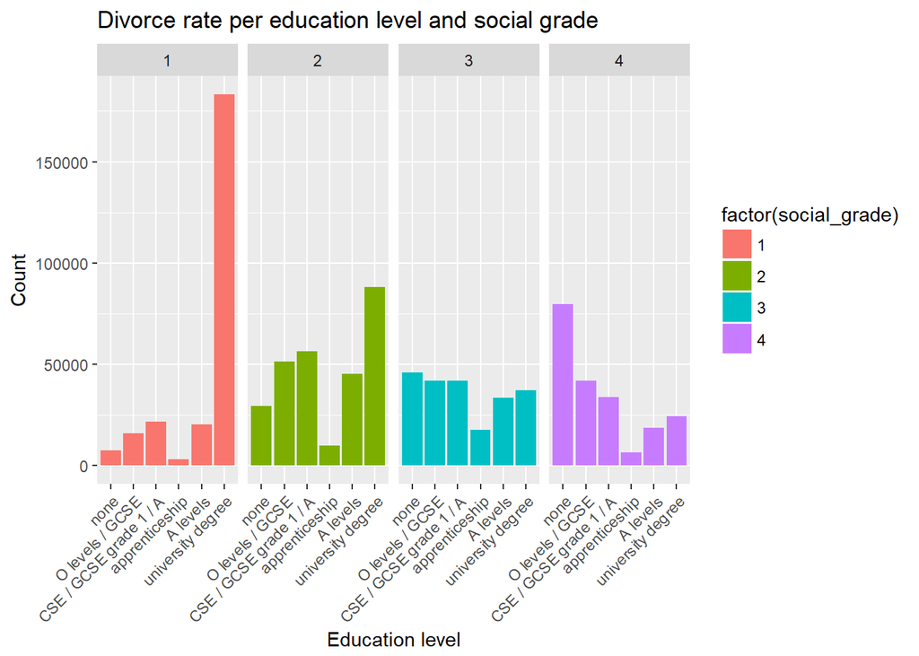

```r
#plot education per social grade, no divorce rate
edu_plot <- ggplot(educ, aes(x = factor(education), y =n, fill = factor(social_grade)))
edu_plot +
  geom_col(stat = "identity") +
  scale_x_discrete(labels = c("10" = "none", "11" = "O levels / GCSE", "12" = "CSE / GCSE grade 1 / A", "13" = "apprenticeship", "14" = "A levels", "15" = "university degree")) +
  ggtitle("Divorce rate per education level and social grade") +
  xlab ("Education level") +
  ylab ("Count") +
  theme(axis.text.x = element_text(angle = 45, hjust = 1)) +
  facet_grid(~social_grade)
```

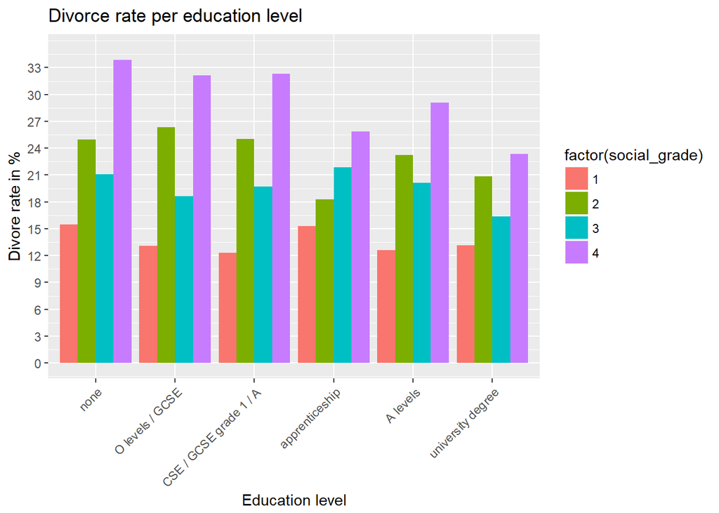

```r
educ <- cen_f %>% group_by(education, social_grade) %>% summarise(n = n(), separated = sum(separated), rel_div = (separated / n)*100) %>% mutate(sg = n/sum(n))

#add seperation per social grade

edu_plot <- ggplot(educ, aes(x = factor(education), y = rel_div, fill = factor(social_grade)))
edu_plot +
  geom_col(stat = "identity", position = "dodge") +
  scale_x_discrete(labels = c("10" = "none", "11" = "O levels / GCSE", "12" = "CSE / GCSE grade 1 / A", "13" = "apprenticeship", "14" = "A levels", "15" = "university degree")) +
  scale_y_continuous(limits = c(0, 35), breaks = seq(0, 35, 3)) +
  ggtitle("Divorce rate per education level") +
  xlab ("Education level") +
  ylab ("Divore rate in %") +
  theme(axis.text.x = element_text(angle = 45, hjust = 1))
```

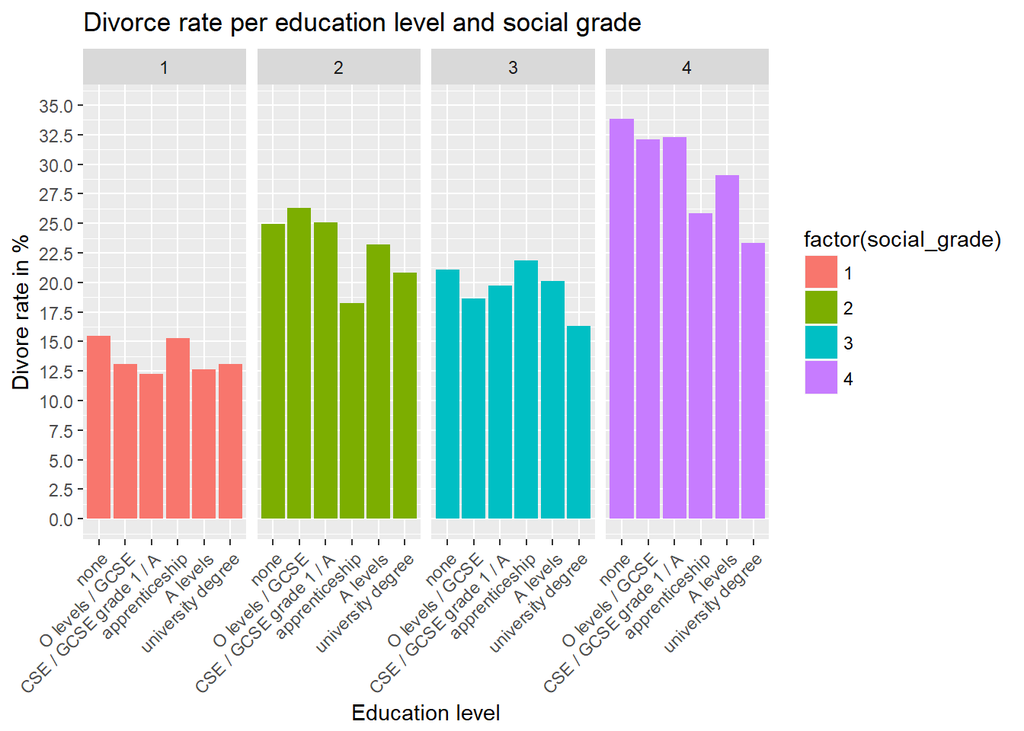

```r
#plot with facet_grid per social grade
####
edu_plot <- ggplot(educ, aes(x = factor(education), y = rel_div, fill = factor(social_grade)))
edu_plot +
  geom_col(stat = "identity") +
  scale_x_discrete(labels = c("10" = "none", "11" = "O levels / GCSE", "12" = "CSE / GCSE grade 1 / A", "13" = "apprenticeship", "14" = "A levels", "15" = "university degree")) +
  scale_y_continuous(limits = c(0, 35), breaks = seq(0, 35, 2.5)) +
  ggtitle("Divorce rate per education level and social grade") +
  xlab ("Education level") +
  ylab ("Divore rate in %") +
  theme(axis.text.x = element_text(angle = 45, hjust = 1)) +
  facet_grid(~social_grade)
```